# Pets, Kids, Politics: Instagram Practices of Democratic Presidental Candidates

Isabelle Langrock

Alexander Tolbert

May 2 2021

# Executive Summary

How do women present themselves when they campaign for the highest office in the United States, where their success would be a landmark victory for gender equality? In the 2019-20 Democratic campaigns more women ran for President than ever before, providing an unprecedented opportunity to understand how women candidates present themselves to the American electorate. We use data sourced from all the Democratic Candidate’s Instagram accounts to understand the gendered differences in self-presentation among presidential candidates.

We first use logistic regression model to predict what image attributes are more likely to predict a woman campaigner as compared to men. We find, that the best predictors are often articles of clothing, themselves highly gendered outside of Instagram. This suggest to us that many of the candidates post similar content, with the best indicators of gender differences these other social indicators. It also suggests the need for continued shcolarship on the relationship between fashion and politics; the ways that clothing can signal likability or competence to a general public and how that is taken advantage of during campaigns. It it striking that in the novel campagin platform like Instagram we continue to see very traditional indicators very important.

Despite the rather null findings of our second model that examines like count, this project testifies to the richness of image data and the urgency for scholarship to investigate how politicians adapt to new formats. The next steps for this project are to extend to other levels of political office and across party.

# Introduction

The rise of social media has opened up new ways for presidential candidates to connect with the electorate, leading to new expectations for campaigns. Personalization, where one’s personality and personal life are made visible to the public through tweets, posts, and pictures has become particularly important to modern politics. Yet expectations of personalization often impact women more, as women candidates must already navigate a double bind that demands they perform as competent politicians in a field long dominated by men and simultaneously fulfill traditionally feminine gender roles (Fiske, Xu, Cuddy, & Glick, 1999; Zulli, 2019). ). Failing to do this impossible task they can be subject to a backlash effect in which the public sees them as either competent or likeable, but never both (Heilman & Okimoto, 2007; Heilman, Wallen, Fuchs, & Tamkins, 2004). Now, women must manage these competing expectations on social media, which has become an important tool for politicians of all genders. These platforms provide a means for candidates to share policy proposals and aspects of their personal lives directly with voters and especially with young voters who frequently engage with politics on primarily visual social media platforms like YouTube and Instagram, rather than the more text-based Facebook and Twitter (Perrin & Anderson, 2019). Past research at the gubernatorial level has shown how women are more likely than men to “self-personalize” in competitive elections, particularly by showing themselves as caregivers, suggesting a strategic awareness of these dynamics among candidates and their campaign staff (McGregor, Lawrence, & Cardona, 2017).

This project investigates the self-personalization practices of presidential candidates through analysis of all the candidates Instagram feeds in 2019. We used a proprietary machine vision service (Amazon Rekognition) to identify objects in each image, which were then manually coded as either political or personal. The analysis presented here uses the full set of labels and images to build a model that predicts gender and one that predicts an engagement score (like count). These are validated on withheld section of our original data. Focus on the objects displayed, rather than assigning the overall image to a single category, both reduces the time and cost of visual coding and allows us to capture the ways that many posts mix politics and personal features: depicting a hug with supporters at a rally or showing a candidate presumably doing work on their phone while in their living room.

We examine two specific research questions in this project:

- 1. Is there a gendered difference in what objects appear in candidate’s Instagram posts?
- 2. Are specific objects associated with a greater amount of engagement (Instagram likes)?

# Data and Analytical Plan

This section briefly reviews our data collection process. Since the bulk of the data collection was completed for a project outside of this class, we describe the process that produced the data analyzed here.

## Data Collection Process

The Instagram accounts were scraped for all posts in early 2020 via the Instagram API. We subsequently used a proprietary machine vision service (Amazon Rekognition) to identify objects in each image, filtered to retain only those images that had a 60% confidence rate. Each label, distinct from the associated image was labeled as either personal or political and a political score was calculated for each image based on the associated labels: $Political_{Score} = \frac{ \sum (labels_ {Political} * CI)}{n_{labels_political}} - \frac{ \sum (labels_{Personal} * CI)}{n_{labels_personal}}$.

The image is our unit of analysis, and in the data analyzed here we have the following variables:

- associated labels
- confidence level for each label
- candidate & candidate username
- date posted (one variable each: month, day, year)
- Whether or not the label is coded as political or personal
- The political score for the image
- Gender
- like count and comment count
- the type of post (photo or video; only photo is analyzed here)
- The start date of the campaign
- The instagram account follower count (as of Jan. 2020)

Details about our use of the Instagram API, the full Amazon Rekognition results, and the manual coding process of the labels into the personal/political categories can be supplied upon request by Isabelle Langrock. This data is part of an ongoing project into the gendered dynamics of presidential campaigns.

## Description of Data

Our data consists of 27 candidates, with 6 women candidates. Despite being roughly 1/4 of our candidate count, the women candidates posts compose just over 30% of the photos analyzed here. This higher mean photo count by the woman is driven by the relative seriousness and high-profile nature of all 6 of their campaigns who all took Instagram seriously as a site for campaigning and reaching voters. While a majority of the men candidates did as well, several of them only rarely posted on Instagram. From *Table 1*, we also see that the woman posted more political images, as a group, than the men, who skewed more personal. These scores indicate that women candidates posted more images with objects that more likely to be identified as political or work related. This fits in line with the need identified in the previous literature for women candidates to present themselves as more competent, as reviewed in the introduction.

```r
# number of candidates and number of posts by gender
post_count_by_gender<- all_data %>%
  group_by(Gender)%>%
  summarise(candidates=n_distinct(username),
            photo_count=n_distinct(finalurl),
            mean_photo_count= photo_count/candidates,
            ave_pol_score=mean(Score))

kable(post_count_by_gender, caption= "Table 1. Number of posts and candidates, by gender", "html") %>%
  kable_styling(bootstrap_options = c("striped", "hover"))
```

Table 1. Number of posts and candidates, by gender

| Gender | candidates | photo_count | mean_photo_count | ave_pol_score |
| --- | --- | --- | --- | --- |
| Female | 6 | 3718 | 619.6667 | 5.650326 |
| Male | 21 | 8093 | 385.3810 | -3.201017 |

Likely due to their greater use of the Instagram platform, the woman candidates also have higher, on average, follower counts than the men. *Figure 1* indicates two outliers: Bernie Sanders and Joe Biden, who have the highest follower counts among all the candidates.

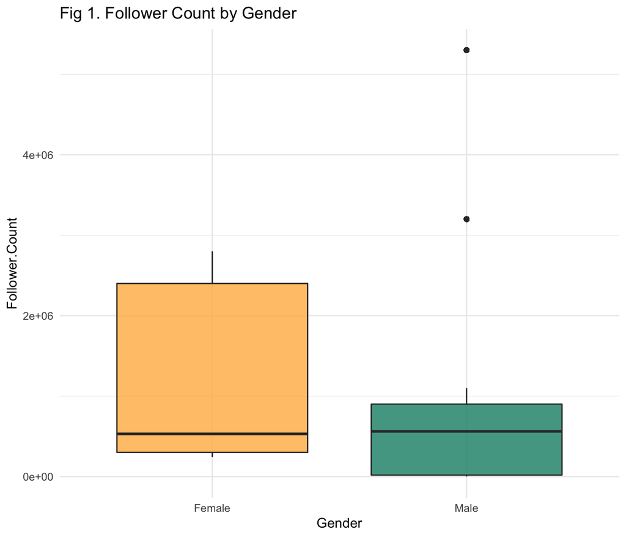

```r
follower_count <- all_data %>%
  select(Follower.Count, Gender) %>%
  ggplot(aes(x=Gender, y=Follower.Count, fill=Gender))+
  geom_boxplot(alpha=.8 )+
  scale_fill_manual(values=c("#ffb74d","#138d75"))+
  ggtitle("Fig 1. Follower Count by Gender")+
  theme_minimal()+
  theme(legend.position="none")

follower_count
```

Figure 2. displays the like counts and comment counts (although these are very slight, and invisible for most) of all the candidates. Notably all of the women candidates are among the top half of candidates in terms of like count and comment count.

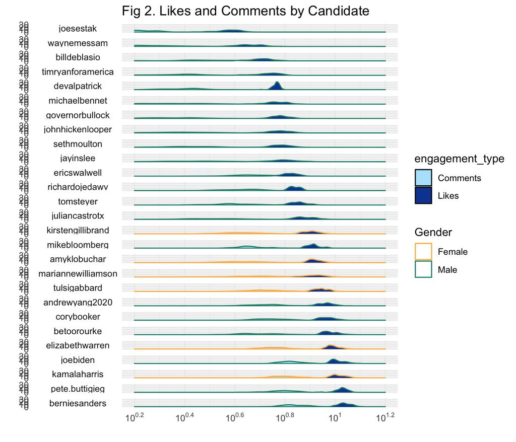

```r
comm_like<- all_data%>%
  pivot_longer(cols=c("commentcount", "likecount"), names_to= "engagement_type", values_to="count")

comm_like$count<-as.numeric(comm_like$count)
comm_like$count<-comm_like$count+1

like_comment_fig<-ggplot(comm_like)+
  geom_density(aes(x=log(count), color=Gender, fill=engagement_type))+
  facet_grid(reorder(username, count)~., switch="y")+
  scale_color_manual(values=c("#ffb74d","#138d75"))+ # Women, then Men for color
  scale_fill_manual(values=c("#b3e5fc", "#0d47a1"), labels=c("Comments", "Likes"))+
  scale_x_continuous(trans= "log10",
                     breaks = trans_breaks("log10", function(x) 10^x),
                     labels = trans_format("log10", math_format(10^.x)),
                     limits=c(10^.2, 10^1.2))+
  xlab("")+
  ylab("")+
  theme_minimal()+
  theme(strip.text.y.left=element_text(angle=0))+
  ggtitle("Fig 2. Likes and Comments by Candidate")

like_comment_fig
```

```r
month_means <- all_data%>%
  group_by(Gender, pubmonth, pubyear)%>%
  summarize(mean=mean(Score)) %>%
  unite(pubmonth, pubyear, pubmonth, sep="-")
```

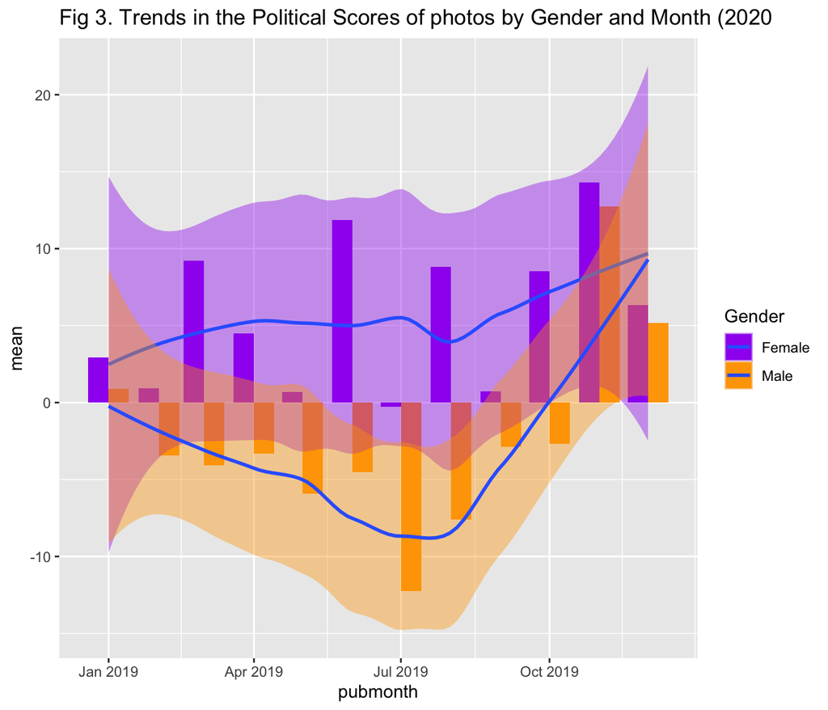

```r
month_means$pubmonth <-as.Date(as.yearmon(month_means$pubmonth))

month_plot_all<-ggplot(month_means, aes(x=pubmonth, y=mean, fill=Gender))+
  geom_bar(stat="identity", position=position_dodge())+
  geom_smooth()+
  scale_fill_manual(values=c("purple", "orange")) +
  ggtitle("Fig 3. Trends in the Political Scores of photos by Gender and Month (2020")

month_plot_all
```

Figures 4 and 5 provide a more qualitative description of the labels in the data set through word clouds of the most frequent labels by category (Fig 4) and by Gender (Fig 5).

**Fig 4. Most Frequent Labels by Category (Objects in images)**

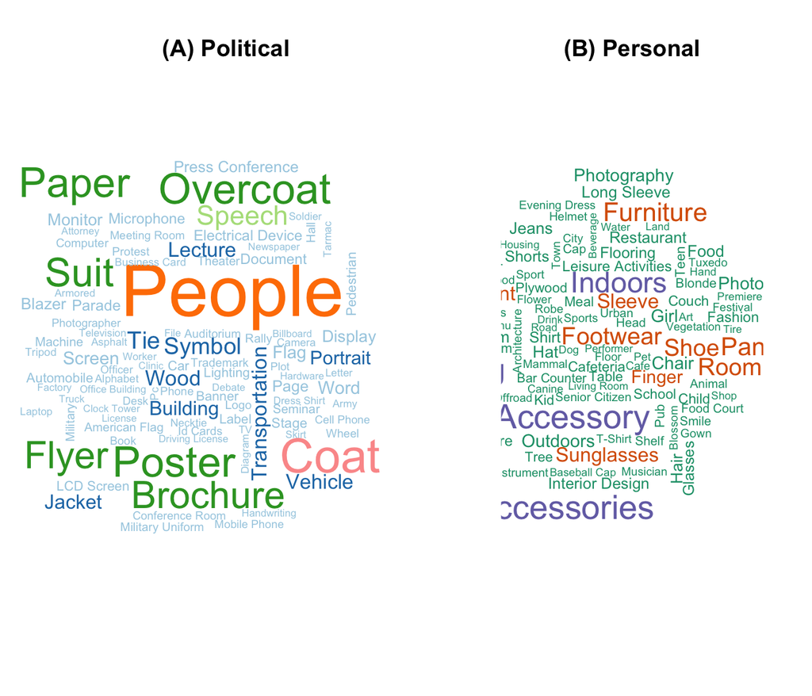

```r
# Top Labels

freq_label<- labels %>%
  count(Gender, username, Political, Name) %>%
  na.omit()

top_label<- freq_label %>%
  filter(Political==1)%>%
  group_by(Name) %>%
  summarise(total_n=sum(n)) %>%
  slice_max(order_by=total_n, n=100)

top.labels<- top_label$Name
top.fre<- top_label$total_n

top_label2<- freq_label %>%
  filter(Political==0)%>%
  group_by(Name) %>%
  summarise(total_n=sum(n)) %>%
  slice_max(order_by=total_n, n=100)
top.labels.2<- top_label2$Name
top.fre.2<- top_label2$total_n


par(mfrow=c(1,2))
col1<- brewer.pal(8, "Paired")
col2<-brewer.pal(8, "Dark2")
wordcloud(top.labels, top.fre, colors=col1, ordered.colors=F)
title("(A) Political")
wordcloud(top.labels.2, top.fre.2, colors=col2, ordered.colors=F)
title("(B) Personal")
```

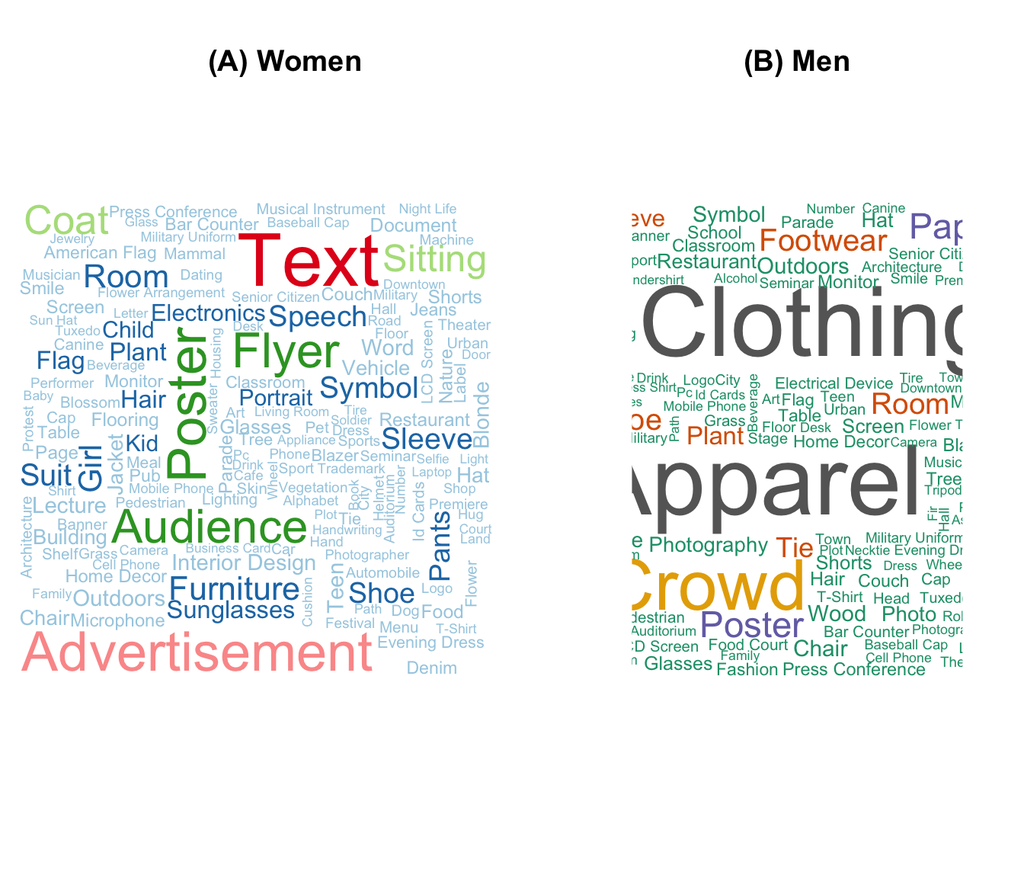

```r
# By Gender
top_w<- freq_label %>%
  filter(Gender=="Female")%>%
  group_by(Name) %>%
  summarise(total_n=sum(n)) %>%
  slice_max(order_by=total_n, n=200)

t_name_w<- top_w$Name
t_fre_w<- top_w$total_n

top_m<- freq_label %>%
  filter(Gender=="Male")%>%
  group_by(Name) %>%
  summarise(total_n=sum(n)) %>%
  slice_max(order_by=total_n, n=200)

t_name_m<- top_m$Name
t_fre_m<- top_m$total_n

par(mfrow=c(1,2))
wordcloud(t_name_w, t_fre_w, colors=col1, ordered.colors=F)
title("(A) Women")
wordcloud(t_name_m, t_fre_m, colors=col2, ordered.colors=F)
title("(B) Men")
```

# Analysis

## Model #1: Predicting gender from image features

The primary aim of this project to investigate if gendered difference exist at the image level, among Democratic candidates for President. To better investigate these we built an optimized logistic model that predicts gender of candidate from the labels of objects in each image.

```r
# for full code see the appendix
x <- model.matrix(Gender~. - likecount - commentcount, data.train)[,-1]

y <- data.train$Gender
#fit1.cv<-cv.glmnet(x, y, alpha=1, family="binomial", nfolds=3, type.measure = "deviance")
# save(fit1.cv, file="Data/fit1_cv.RData")
load("Data/fit1_cv.Rdata")

coef.1se<- coef(fit1.cv, s="lambda.1se")
coef.1se<- coef.1se[which(coef.1se!=0),]

beta.min <- rownames(as.matrix(coef.1se))
data.train.min <- data.train %>%
  select(Gender, one_of(beta.min), - Jeans, -Accessory, -Flyer)

fit1_forward <- regsubsets(Gender~., data.train.min, nvmax=35, method="forward")

ff1<- summary(fit1_forward)

ff_final<- ff1$which
final_variables <- colnames(ff_final)[ff_final[25,]][-1]
final_input <- as.formula(paste("Gender", "~", paste(final_variables, collapse="+")))

glm_fit1 <- glm(final_input, family=binomial, data=data.train)
```

```r
print(xtable(glm_fit1), type="html")
```

|  | Estimate | Std. Error | z value | Pr(>\|z\|) |
| --- | --- | --- | --- | --- |
| (Intercept) | -0.1240 | 0.0685 | -1.81 | 0.0701 |
| Abies | -0.0190 | 0.0082 | -2.32 | 0.0203 |
| Apparel | -0.0022 | 0.0008 | -2.70 | 0.0070 |
| Back | 0.0207 | 0.0084 | 2.48 | 0.0133 |
| Banister | -0.0215 | 0.0077 | -2.81 | 0.0049 |
| Chair | -0.0046 | 0.0014 | -3.21 | 0.0013 |
| Dating | 0.0166 | 0.0042 | 4.00 | 0.0001 |
| Fashion | 0.0062 | 0.0019 | 3.25 | 0.0011 |
| Female | 0.0131 | 0.0017 | 7.69 | 0.0000 |
| Flag | 0.0115 | 0.0014 | 8.32 | 0.0000 |
| Food | -0.0067 | 0.0016 | -4.15 | 0.0000 |
| Hair | 0.0040 | 0.0016 | 2.48 | 0.0133 |
| Human | -0.0045 | 0.0008 | -5.39 | 0.0000 |
| Jewelry | 0.0238 | 0.0083 | 2.87 | 0.0041 |
| Outdoors | -0.0052 | 0.0015 | -3.49 | 0.0005 |
| Pants | -0.0065 | 0.0013 | -4.98 | 0.0000 |
| People | -0.0050 | 0.0009 | -5.57 | 0.0000 |
| Plot | -0.0131 | 0.0039 | -3.32 | 0.0009 |
| Scarf | 0.0253 | 0.0086 | 2.95 | 0.0032 |
| Shirt | -0.0297 | 0.0035 | -8.42 | 0.0000 |
| Shorts | -0.0054 | 0.0019 | -2.85 | 0.0043 |
| Sleeve | 0.0090 | 0.0014 | 6.25 | 0.0000 |
| Suit | -0.0086 | 0.0012 | -6.98 | 0.0000 |
| Surfing | 0.1776 | 2.3148 | 0.08 | 0.9388 |
| Tie | -0.0087 | 0.0017 | -5.04 | 0.0000 |
| Woman | 0.0064 | 0.0023 | 2.78 | 0.0054 |

We then test this model on our validation data set (40% of the original data) and get an AUC of 0.7. We think this is a pretty impressive prediction rate for our model, specifically since it is based off of only 25 image objects.

```r
fit.final.test <- predict(glm_fit1, data.validate, type="response")

fit.final.roc <- roc(data.validate$Gender, fit.final.test)
```

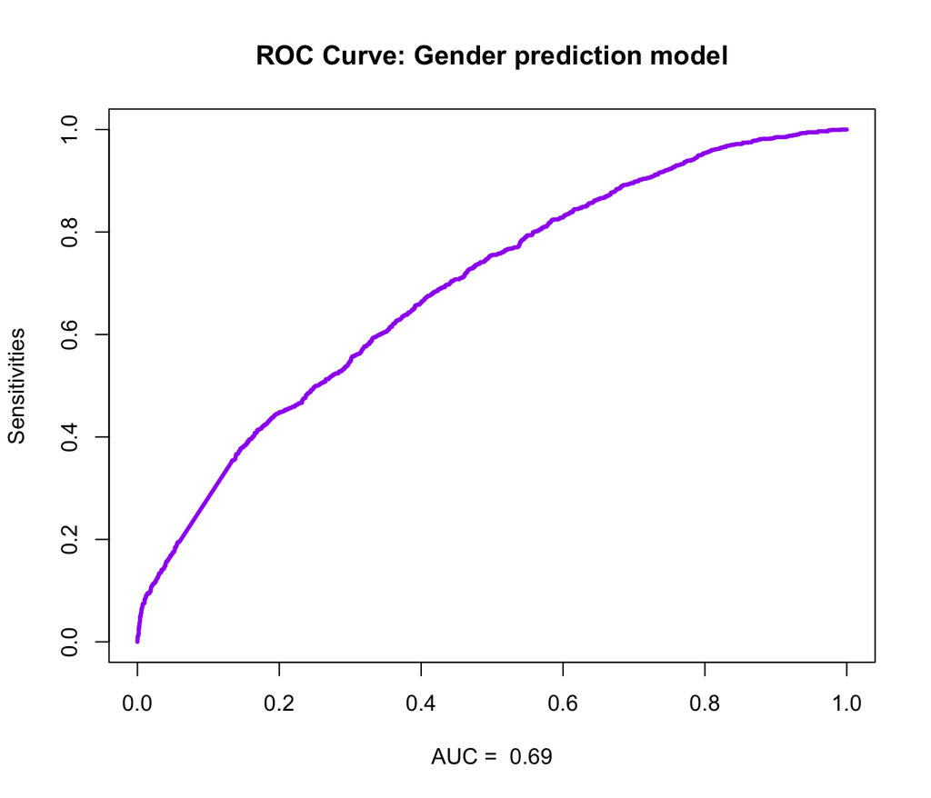

```r
plot(1-fit.final.roc$specificities, fit.final.roc$sensitivities,
     col="purple", type="l", lwd = 3,
     xlab=paste("AUC = ", round(pROC::auc(fit.final.roc), 2)),
     ylab="Sensitivities")
title("ROC Curve: Gender prediction model")
```

The quality of our model, and its performance on our test set suggests that it is indeed possible to differentiate men and women candidates based on objects in the images they post. However closer look at the variables in our final model suggest that is mostly due to clothing items, which reflect wider gendered trends in self personalization (for example, the increase likelihood of a candidate being a woman if the image includes jewelry). Clothing is the best indicator between men and women presidential candidates, suggesting a need for more scholarship on the importance of clothing in politics, particularly as a means to either encourage likeability or as a signal of competence, and how this might vary between men and women.

## Model #2: Predicting likes from images features

Our second model investigates th relationship among objects in images and the popularity (via likes) of those images. To build this model we use LASSO selection and a linear regression model to identify a parsimonious model for predicting the image like count. Full details of this process are described in the appendix. Unfortunately the model using the image labels is not good and violates a lot of our linear and heteroscedasticity assumptions. (See Appendix for the diagnostics run). A simple model using gender and follower count is a much better fit for the data. Together these two models suggest that while there are certain objects that garner more likes (pets, like dogs and turles, for instance) and less likes (schools) the best way to boost like count is to increase follower count.

```r
print(xtable(m1), type="html")
```

|  | Estimate | Std. Error | t value | Pr(>\|t\|) |
| --- | --- | --- | --- | --- |
| (Intercept) | 7925.0122 | 1057.4834 | 7.49 | 0.0000 |
| Advertisement | -58.3150 | 9.4248 | -6.19 | 0.0000 |
| Art | -100.2260 | 30.1724 | -3.32 | 0.0009 |
| Atlas | 295.6686 | 80.8406 | 3.66 | 0.0003 |
| Banner | -116.0052 | 25.1474 | -4.61 | 0.0000 |
| Bridge | 283.6994 | 72.0977 | 3.93 | 0.0001 |
| Clothing | -35.6411 | 7.3928 | -4.82 | 0.0000 |
| Cloud | 1006.0696 | 224.2378 | 4.49 | 0.0000 |
| Coin | 476.6184 | 147.4289 | 3.23 | 0.0012 |
| Collage | 330.0433 | 49.0399 | 6.73 | 0.0000 |
| Culinary | 600.2912 | 195.9294 | 3.06 | 0.0022 |
| Electronics | -52.2056 | 13.8106 | -3.78 | 0.0002 |
| Face | 36.6020 | 9.6649 | 3.79 | 0.0002 |
| Family | 136.5491 | 38.0694 | 3.59 | 0.0003 |
| Indoors | -44.2343 | 10.5602 | -4.19 | 0.0000 |
| Logo | 276.8735 | 32.0858 | 8.63 | 0.0000 |
| Outdoors | -55.0831 | 13.9180 | -3.96 | 0.0001 |
| Page | 88.8634 | 21.7813 | 4.08 | 0.0000 |
| Pants | -53.1656 | 10.8308 | -4.91 | 0.0000 |
| Person | 128.0371 | 10.1448 | 12.62 | 0.0000 |
| Pet | 151.7826 | 31.1036 | 4.88 | 0.0000 |
| Police | 600.8178 | 180.4479 | 3.33 | 0.0009 |
| Raincoat | 838.0276 | 223.4950 | 3.75 | 0.0002 |
| Restaurant | -97.0017 | 14.7090 | -6.59 | 0.0000 |
| School | -69.9761 | 20.2776 | -3.45 | 0.0006 |
| Text | 119.4234 | 9.4693 | 12.61 | 0.0000 |
| Word | -61.4819 | 17.7585 | -3.46 | 0.0005 |
| `Arcade Game Machine` | 1047.4560 | 149.4625 | 7.01 | 0.0000 |
| `Box Turtle` | 710.2223 | 214.7869 | 3.31 | 0.0009 |
| `Golden Retriever` | 198.6817 | 60.3243 | 3.29 | 0.0010 |
| `Press Conference` | -71.8480 | 20.5335 | -3.50 | 0.0005 |

```r
m2 <- lm(likecount~Follower.Count + Gender + Score, data=all_data)
print(xtable(m2), type="html")
```

|  | Estimate | Std. Error | t value | Pr(>\|t\|) |
| --- | --- | --- | --- | --- |
| (Intercept) | -626.0934 | 427.5317 | -1.46 | 0.1431 |
| Follower.Count | 0.0129 | 0.0001 | 91.41 | 0.0000 |
| GenderMale | 4650.2204 | 470.7638 | 9.88 | 0.0000 |
| Score | 2.3137 | 3.9424 | 0.59 | 0.5573 |

While high follower counts also have higher like counts on individual pictures is a rather obvious conclusion, the evidence for it here suggests important new directions for studying how campaigns operate on social media platforms. Specifically it should prompt us into better understanding how candidates can grow their follower base, particularly among young voters who they are more likely to encounter on a platform like Instagram than through traditional media or even other social media networking sites like Facebook or Twitter. While we do not have this data, our findings are promising for future research.

# Conclusions

This project used an original data set of instagram posts by the 2020 Democratic primary candidates to better understand the behavior they engage in on Instagram and if there are gendered differences. We find that the old differences, particularly around how candidates use clothing to express themselves, are still important in contemporary campaigns. We also look at what image objects are best able to predict like count and surfaced an intersecting, if poorly predictive, model. Indeed, follower count is a much better predictor than anything else.

Our analysis is limited in its scope of only democratic and only presidential candidates. It thus perhaps overestimates based on individuals particularities, and subsequent analysis should extend to other races and other parties, as well as other countries. We also use a data set that is perhaps to empty to be of best results here, with most variables having just a few associated variables (and otherwise being mostly 0). Treating these as categorical indicator variables would be a good robustness check, although is not completed here.

In all, we find that this project is able to shed some light into an emerging phenomenon (more women running for President) on understudied platform (Instagram). Our findings will hopefully encourage more women to run for politics mainly through its description of what the 2020 candidates posted and featured on their account. We hope this work contributes to the ongoing efforts of better understanding the gender biases that maintain gender inequities among US politicians.

# References

Fiske, S. T., Xu, J., Cuddy, A. C., & Glick, P. (1999). (Dis)respecting versus (Dis)liking: Status and Interdependence Predict Ambivalent Stereotypes of Competence and Warmth. Journal of Social Issues, 55(3), 473–489. https://doi.org/10.1111/0022-4537.00128

Heilman, M. E., & Okimoto, T. G. (2007). Why are women penalized for success at male tasks?: The implied communality deficit. Journal of Applied Psychology, 92(1), 81-92.

Heilman, M. E., Wallen, A. S., Fuchs, D., & Tamkins, M. M. (2004). Penalties for Success: Reactions to Women Who Succeed at Male Gender-Typed Tasks. Journal of Applied Psychology, 89(3), 416-427.

McGregor, S. C., Lawrence, R. G., & Cardona, A. (2017). Personalization, gender, and social media: gubernatorial candidates’ social media strategies. Information, Communication & Society, 20(2), 264–283.

Zulli, D. (2019). Towards a Conception of the “Mythic Presidency:” Hillary Clinton, Donald Trump, and the Visual Politics of Gender on Instagram. In Montalbano, L. (Ed.) Gender, Race, and Social Identity in American Politics: The Past and Future of Political Access. Lanham: Lexington Books.